# Eksploracja danych z Have Your Say

## Import

```python
from google.colab import drive
drive.mount('/content/drive')
```

```python
import pandas as pd
import numpy as np
import spacy
```

```python
!python -m spacy download en_core_web_md
# trzeba uruchomić ponownie środowisko wykonawcze po pobraniu
```

```python
!pip install PyPDF2
```

```python
! pip install swifter
! pip install matplotlib==3.1.3
```

```python
en = spacy.load("en_core_web_md")
```

```python
from PyPDF2 import PdfFileReader
import os
import swifter
import pickle
from collections import Counter
from tqdm import tqdm
import seaborn as sns
import matplotlib.pyplot as plt
sns.set_theme(style="whitegrid")
```

```python
DIR = '/content/drive/MyDrive/NLP-klimat/'
```

## Dane z Have Your Say

Wczytanie dokumentów załączonych do uwag otrzymanych w ramach konsultacji publicznych dotyczących trzech inicjatyw publicznych:

- Europejski Pakt na rzecz Klimatu - `climate_pact`

  > Sposobem na promowanie powszechnej mobilizacji społecznej jest „pakt na rzecz klimatu”, który ma zjednoczyć obywateli, przedsiębiorców, społeczeństwo obywatelskie i organy publiczne.
- Plan w zakresie celów klimatycznych na 2030 r. - `climate_plan`

  > Celem konsultacji jest zebranie opinii na temat pożądanego poziomu ambicji polityki w zakresie klimatu i energii, niezbędnych działań w różnych sektorach oraz konkretnych strategii politycznych służących zwiększeniu poziomu ambicji w dziedzinie klimatu do 2030 r. Konsultacje mają również na celu zebranie dalszych informacji, w tym planów działania, wytycznych politycznych i badań dotyczących dalszej redukcji emisji gazów cieplarnianych.
- Europejskie prawo o klimacie - `climate_law`

  > Europejskie prawo o klimacie stanowi gwarant tego, że wszystkie polityki Unii Europejskiej, sektory gospodarki i grupy społeczne będą dążyć do realizacji celu Europejskiego Zielonego Ładu, ale też tego, że przejście na neutralność klimatyczną będzie nieodwracalne.

Najpierw przystąpimy do analizy pierwszych dwóch dokumentów, gdyż dla nich dostępne są do pobrania wyniki konsultacji w formie pliku `.csv` i pdf-owych załączników.

#### Wczytanie danych

```python
climate_pact_files_list = os.listdir(DIR+'attachments-EuropeanClimatePact')
climate_plan_files_list = os.listdir(DIR+'attachments-eu_climate_ambition_2030')
```

```python
climate_pact_consultation = []
for file_name in tqdm(climate_pact_files_list):
  file = open(DIR+'attachments-EuropeanClimatePact/'+file_name, 'rb')
  fileReader = PdfFileReader(file)
  num_pages = fileReader.numPages
  count = 0
  text = ""
  #The while loop will read each page.
  while count < num_pages:
      pageObj = fileReader.getPage(count)
      count +=1
      text += pageObj.extractText()
  climate_pact_consultation.append(text)
```

```python
climate_plan_consultation = []
for file_name in tqdm(climate_plan_files_list):
  file = open(DIR+'attachments-eu_climate_ambition_2030/'+file_name, 'rb')
  fileReader = PdfFileReader(file)
  num_pages = fileReader.numPages
  count = 0
  text = ""
  #The while loop will read each page.
  while count < num_pages:
      pageObj = fileReader.getPage(count)
      count +=1
      text += pageObj.extractText()
  climate_plan_consultation.append(text)
```

```python
climate_pact_df = pd.DataFrame({"filename": climate_pact_files_list, "text": climate_pact_consultation})
climate_plan_df = pd.DataFrame({"filename": climate_plan_files_list, "text": climate_plan_consultation})
```

#### Analiza wstępna

##### Pakt

Niestety w przypadku Paktu identyfikatory załączonych dokumentów (obecne w nazwach plików PDF) nie są zgodne z identyfikatorami z tabeli opisującej odpowiedzi ankietowanych biorących udział w konsultacjach, co uniemożliwia jednoznaczną identyfikację.

```python
climate_pact_contributions = pd.read_csv(DIR+'contributions-EuropeanClimatePact.csv', sep=";", on_bad_lines='skip')
climate_pact_contributions.Reference
```

```
0       F531731
1       F531730
2       F531729
3       F531728
4       F531727
         ...
3504    F507820
3505    F507811
3506    F507810
3507    F516509
3508    F507801
Name: Reference, Length: 3509, dtype: object
```

```python
climate_pact_df.filename.str.partition("_")[0]
```

```
0      PP670
1        PP1
2       PP18
3       PP27
4       PP28
       ...
96     PP656
97     PP377
98     PP319
99     PP317
100    PP375
Name: 0, Length: 101, dtype: object
```

##### Plan

Dla Planu ID załączników są na szczęście odpowiednie, więc można połączyć załączniki z informacjami z tabeli.

```python
climate_plan_contributions = pd.read_csv(DIR+'contributions-eu_climate_ambition_2030.csv', sep=";", on_bad_lines='skip')
```

```python
climate_plan_df["Reference"] = climate_plan_df.filename.str.partition("-")[0]
climate_plan_df = climate_plan_df.set_index("Reference").join(climate_plan_contributions.set_index("Reference"), how='left').reset_index()
```

```python
climate_plan_df = pd.read_csv(DIR+"climate_plan_df.csv")
```

```python
len(climate_plan_df)
```

```
359
```

Mamy 359 załączników PDF połączonych z odpowiedziami w ankiecie.

Niestety podział na kraje jest niemożliwy ze względu na niewielką liczność danych jeśli chodzi o załączone PDF, w szczególności po angielsku. Wykorzystamy więc podział na typy aktorów.

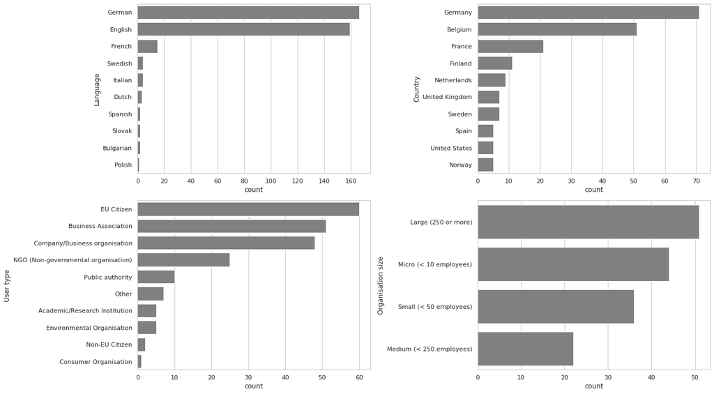

```python
fig, axs = plt.subplots(2, 2, figsize=(18, 10))
i, j = 0, 0
for var in ["Language", "Country", "User type", "Organisation size"]:
  sns.countplot(ax=axs[i][j], y=var, data=climate_plan_df,
                order=climate_plan_df[var].value_counts().iloc[:10].index,
                color="grey")
  j += 1
  if j > 1:
    i+=1
    j=0
fig.tight_layout()
plt.show()
```

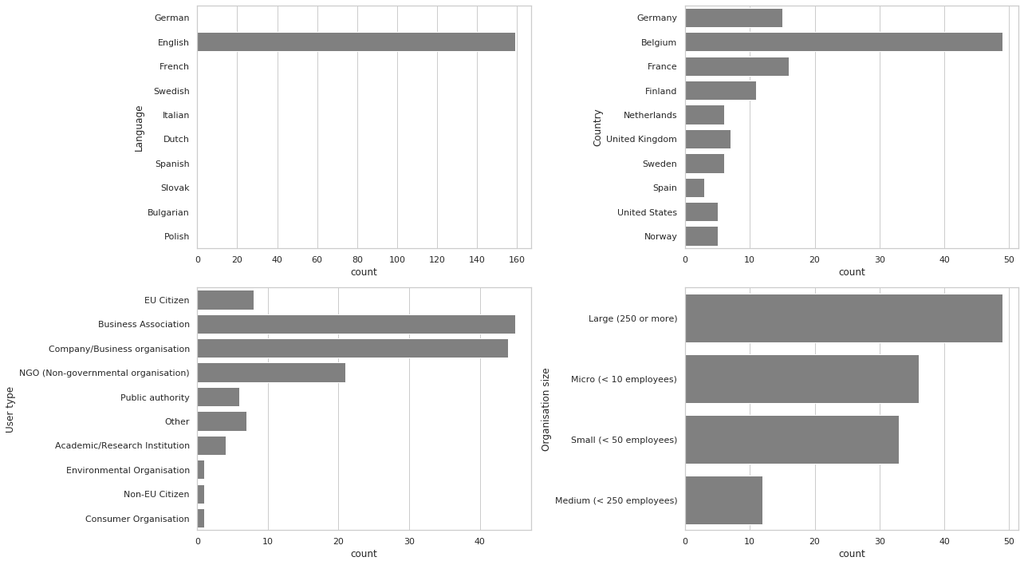

```python
fig, axs = plt.subplots(2, 2, figsize=(18, 10))
i, j = 0, 0
for var in ["Language", "Country", "User type", "Organisation size"]:
  sns.countplot(ax=axs[i][j], y=var, data=climate_plan_df[climate_plan_df.Language == "English"],
                order=climate_plan_df[var].value_counts().iloc[:10].index,
                color="grey")
  j += 1
  if j > 1:
    i+=1
    j=0
fig.tight_layout()
plt.show()
```

Podejrzany rozkład w przypadku Belgii sugeruje, by sprawdzić, czy wszystko jest w porządku. Po obejrzeniu danych dokładniej okazuje się, że do jednej odpowiedzi może być kilka załączników.

```python
climate_plan_df.Reference.value_counts()
```

```
F512857    6
F514893    4
F534473    3
F532255    3
F534105    3
          ..
F533243    1
F533252    1
F533265    1
F533270    1
F535258    1
Name: Reference, Length: 310, dtype: int64
```

##### Prawo

```python
climate_law_df = pd.read_csv(DIR+'climate_law_feedback.csv')
```

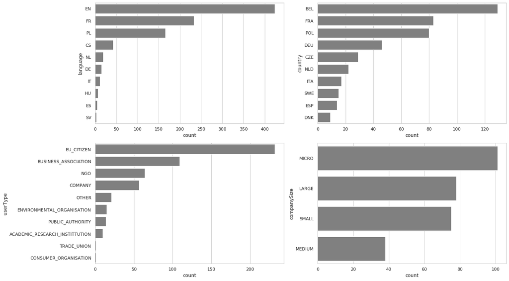

```python
fig, axs = plt.subplots(2, 2, figsize=(18, 10))
i, j = 0, 0
for var in ["language", "country", "userType", "companySize"]:
  sns.countplot(ax=axs[i][j], y=var, data=climate_law_df,
                order=climate_law_df[var].value_counts().iloc[:10].index,
                color="grey")
  j += 1
  if j > 1:
    i+=1
    j=0
fig.tight_layout()
plt.show()
```

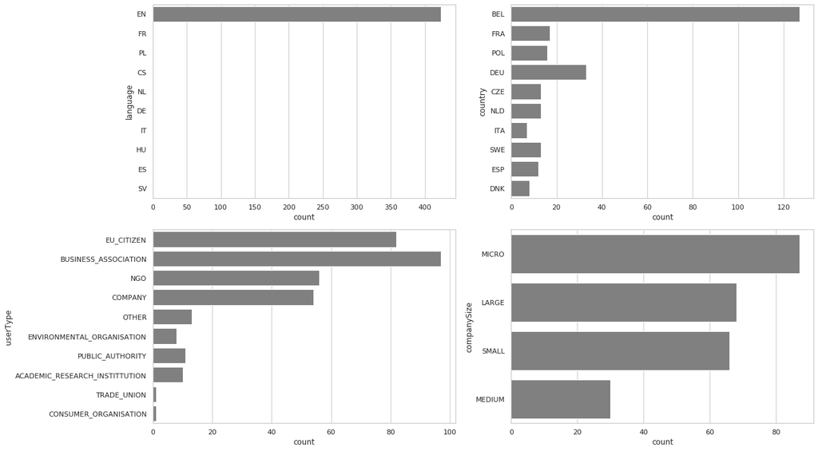

```python
fig, axs = plt.subplots(2, 2, figsize=(18, 10))
i, j = 0, 0
for var in ["language", "country", "userType", "companySize"]:
  sns.countplot(ax=axs[i][j], y=var, data=climate_law_df[climate_law_df.language =="EN"],
                order=climate_law_df[var].value_counts().iloc[:10].index,
                color="grey")
  j += 1
  if j > 1:
    i+=1
    j=0
fig.tight_layout()
plt.show()
```

### Analiza tekstów

#### Analiza dla Prawa

```python
climate_law_df = climate_law_df[climate_law_df.language == "EN"]
```

```python
tqdm.pandas()
climate_law_docs = climate_law_df['feedback'].swifter.apply(en)
```

```python
# eksport przetworzonych dokumentów
with open(DIR + 'climate_law_docs.pickle', 'wb') as f:
  pickle.dump(climate_law_docs, f)
```

```python
# eksport przetworzonych dokumentów
with open(DIR + 'climate_law_docs.pickle', 'rb') as f:
  climate_law_docs = pickle.load(f)
```

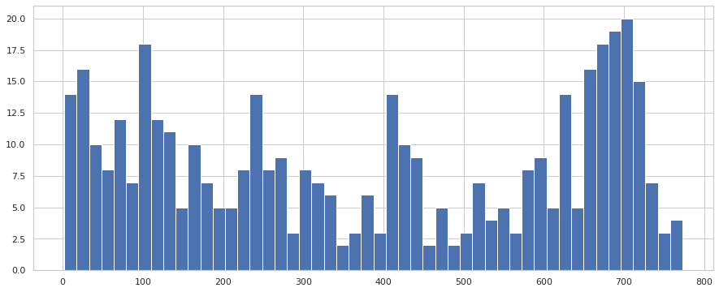

```python
plt.figure(figsize=(15,6))
climate_law_df["length"] = climate_law_docs.str.len()
climate_law_df["length"].hist(bins = 50)
plt.show()
```

```python
def plot_counter(counter: Counter, orient: str = 'h', color: str='lightblue', figsize: tuple=(20,13)):
  plt.figure(figsize=figsize)
  keys = [k[0] for k in counter]
  vals = [int(k[1]) for k in counter]
  ax = sns.barplot(x=vals, y=keys, orient=orient, color=color)
  return ax
```

```python
climate_law_df["lemmas"] = climate_law_docs.apply(lambda doc: [token.lemma_ for token in doc if not token.is_stop if not token.is_punct if token.is_alpha])
climate_law_counter = Counter(climate_law_df["lemmas"].sum()).most_common(30)
```

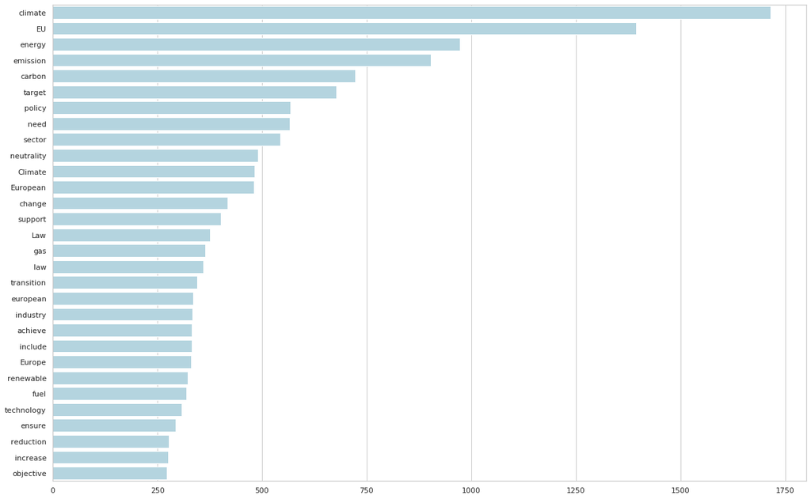

```python
plot_counter(climate_law_counter)
plt.show()
```

```python
from sklearn.feature_extraction.text import CountVectorizer
```

```python
cv = CountVectorizer(stop_words = en.Defaults.stop_words, ngram_range=(2, 2))
count_vector = cv.fit_transform(climate_law_df['feedback'].values)
sum_ngram = count_vector.sum(axis=0)
ngram_freq = [(ngram, sum_ngram[0, idx])
              for ngram, idx in cv.vocabulary_.items()]
ngram_freq = sorted(ngram_freq, key = lambda x: x[1], reverse=True)
```

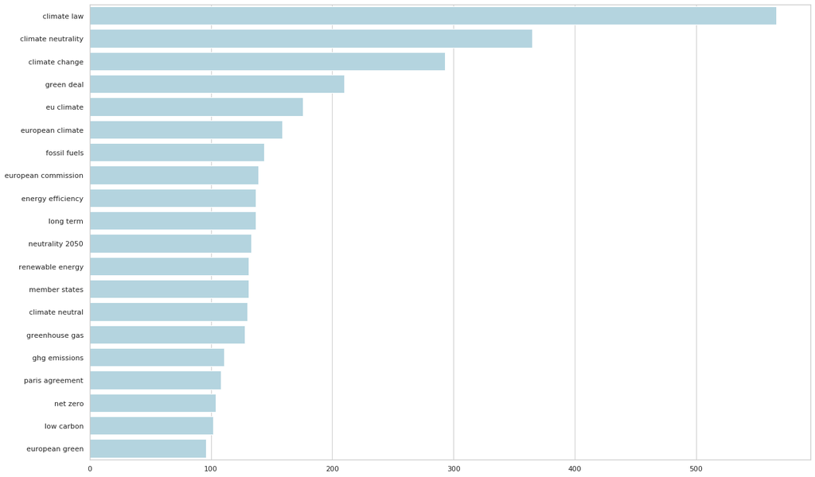

```python
plot_counter(ngram_freq[:20])
plt.show()
```

```python
cv3 = CountVectorizer(stop_words = en.Defaults.stop_words, ngram_range=(3, 3))
count_vector3 = cv3.fit_transform(climate_law_df['feedback'].values)
sum_ngram3 = count_vector3.sum(axis=0)
ngram_freq3 = [(ngram, sum_ngram3[0, idx])
              for ngram, idx in cv3.vocabulary_.items()]
ngram_freq3 = sorted(ngram_freq3, key = lambda x: x[1], reverse=True)
```

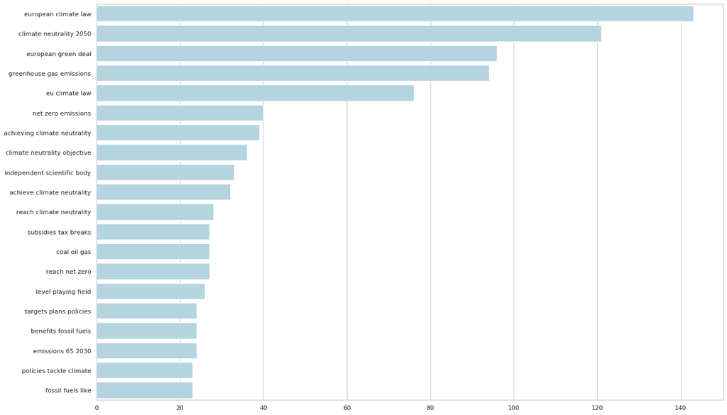

```python
plot_counter(ngram_freq3[:20])
plt.show()
```

#### Analiza dla Planu

Niestety w przypadku odpowiedzi dotyczących Planu nie udało się poprawnie odczytać PDF-ów, wiele z nich jest po prostu pojedynczymi wykresami, więc ewentualna praca z tymi danymi wymaga jeszcze ręcznego przejrzenia dokumentów.

```python
tqdm.pandas()
climate_plan_docs = climate_plan_df['text'].swifter.apply(en)
```

```python
# eksport przetworzonych dokumentów
with open(DIR + 'climate_plan_docs.pickle', 'wb') as f:
  pickle.dump(climate_plan_docs, f)
```

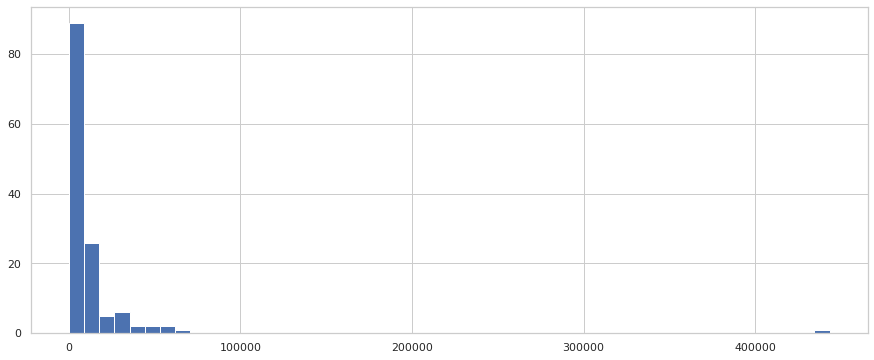

```python
plt.figure(figsize=(15,6))
climate_plan_df["length"] = climate_plan_docs.str.len()
climate_plan_df["length"].hist(bins = 50)
plt.show()
```

```python
climate_plan_df["necp_lemmas"] = climate_plan_docs.apply(lambda doc: [token.lemma_ for token in doc if not token.is_stop if not token.is_punct if token.is_alpha])
climate_plan_counter = Counter(climate_plan_df["necp_lemmas"].sum()).most_common(30)
```

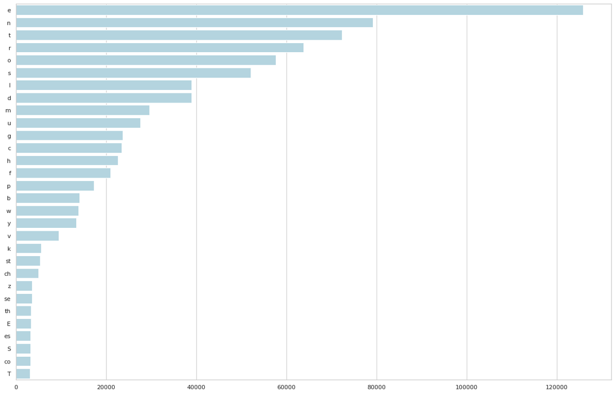

```python
plot_counter(climate_plan_counter)
plt.show()
```

Konieczne jest poprawienie wczytywania PDF.

```python
jupyter nbconvert --to html notebook.ipynb
```